# BIOS 7323 Lab 5

2017-10-01

### Objectives

Perform 1 and 2 sample hypothesis tests in R

#### One sample hypothesis tests

A review of the tongue cancer literature found two previous manuscripts that used parametric models for overall survival. The first paper used an exponential model with $\lambda=0.009$ (i.e. $S(t)=\exp(-0.009t)$) while the second paper used a log-logistic model with $\lambda=0.016$ and $\alpha=1$ ($S(t)=\frac{1}{1+0.016t}$).

We can test whether the data are consistent with a specific distribution by calculating the expected probability of survival at each time in our dataset and including these times as an offset term in the formula argument of survdiff().

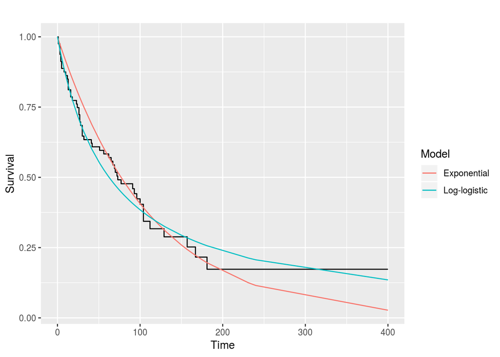

```r
#load the tongue cancer data and create a plot that shows the K-M estimate for overall survival (ignoring tumor type) and the two parametric models from the previous papers:
# exponential with lambda = 0.009,
# log-logistic with lambda = 0.016, alpha = 1
data(tongue)

tongsurv<-survfit(Surv(time,delta)~1,data=tongue)

# plot using ggplot
tongueplot<-ggsurv(tongsurv,CI=FALSE,plot.cens=FALSE)

tongueplot+
  geom_line(aes(x=time,y=exp(-time*0.009),color="Exponential"))+
  geom_line(aes(x=time,y=1/(1+0.016*time),color="Log-logistic"))+
  guides(color=guide_legend(title="Model"))
```

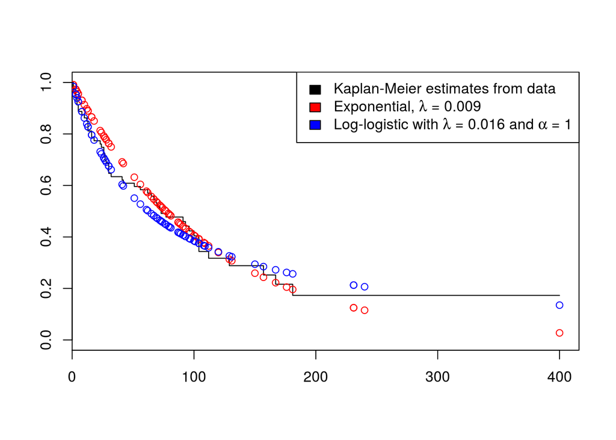

```r
# using base R
plot(tongsurv,conf.int = FALSE)
with(tongue,points(time,exp(-time*0.009),col="red"))
with(tongue,points(time,1/(1+0.016*time),col="blue"))
legend("topright", fill = c("black", "red", "blue"),
legend = c("Kaplan-Meier estimates from data",
expression(paste("Exponential, ",lambda, " = 0.009", sep = "")),
expression(paste("Log-logistic with ",lambda, " = 0.016 and ", alpha, " = 1", sep = ""))))
```

```r
# perform 2 one sample log-rank tests to determine if the data is consistent with the previous parametric models.
# Hint: use offset(expected_survival) on the right side of the survdiff() formula

# exponential with lambda = 0.009,
survdiff(Surv(time,delta)~offset(exp(-time*0.009)),data=tongue)
```

```
## Call:
## survdiff(formula = Surv(time, delta) ~ offset(exp(-time * 0.009)),
##     data = tongue)
##
## Observed Expected        Z        p
##  53.0000  53.1540   0.0211   0.9830
```

```r
# log-logistic with lambda = 0.016, alpha = 1
survdiff(Surv(time,delta)~offset(1/(0.016*time+1)),data=tongue)
```

```
## Call:
## survdiff(formula = Surv(time, delta) ~ offset(1/(0.016 * time +
##     1)), data = tongue)
##
## Observed Expected        Z        p
##   53.000   54.412    0.191    0.848
```

```r
# Are the data consistent with the parametric models?
```

#### 2+ Sample hypothesis tests with no covariates

In the bone marrow transplant (bmt) data, suppose investigators are interested in the association between receiving methotrexate (MTX) as a graft-vs-host prophylactic and time to either death or relapse (disease-free survival).

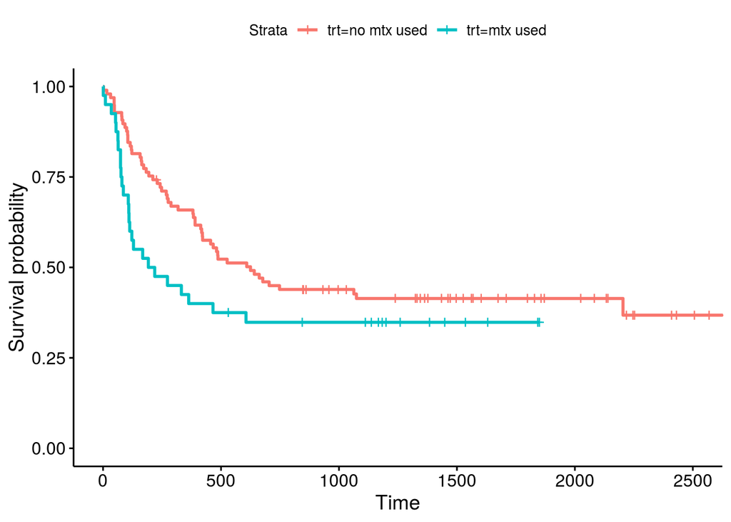

```r
# use the bmt data to create a dataset with event time and indicator for disease-free survival as well as MTX treatment status and disease group (ALL, AML low risk, AML high risk)
data(bmt)

bmt_dat <- bmt %>% as.tibble() %>% select(group,t2,d3,z10) %>%
  rename(trt=z10) %>%
  mutate(trt=recode_factor(trt,`0`="no mtx used",`1`="mtx used"),
         group=recode_factor(group,`1`="ALL",`2`="AML low",`3`="AML high"))

# plot Kaplan-Meier disease-free survival curves for each treatment group
# make sure to add a legend or label
bmtfit <- survfit(Surv(t2,d3)~trt, data=bmt_dat)

survminer::ggsurvplot(bmtfit)
```

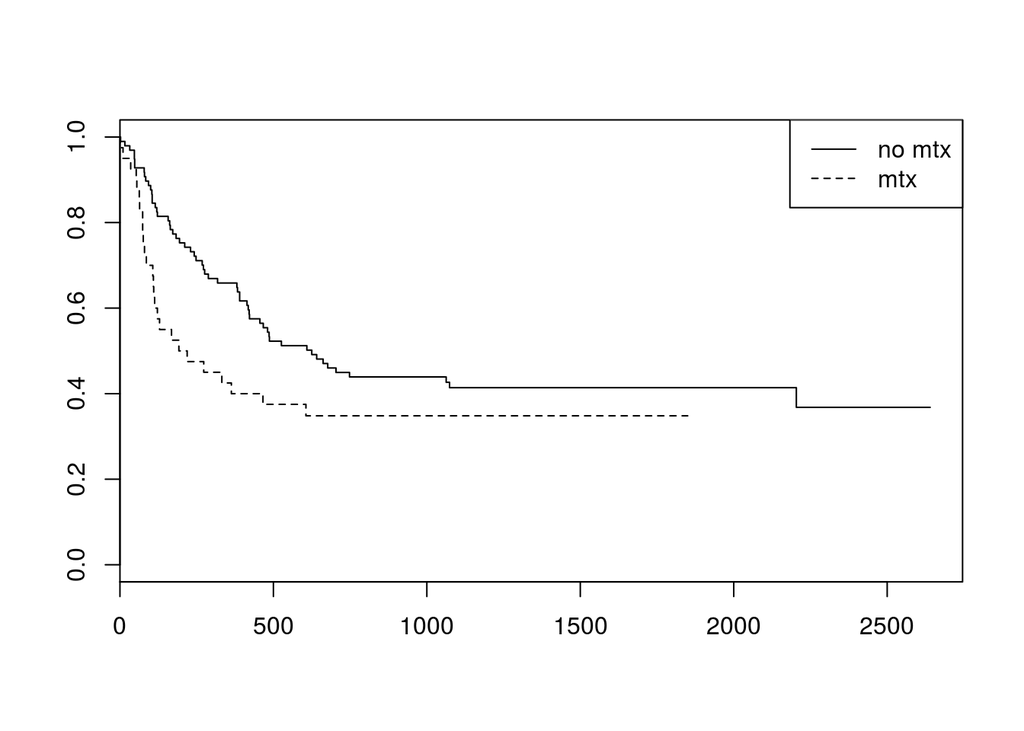

```r
# base R
plot(bmtfit, lty=c(1,2))
legend("topright", legend=c("no mtx", "mtx"), lty=c(1,2))
```

Test the hypothesis that the hazard rate is same for both MTX treatment groups at all time points vs. the alternative that hazard rates differ at some time point.

```r
# Use survdiff() to perform a log-rank test of the hypothesis that the hazard rate is same for both treatment groups
( bmttest_lr<-survdiff(Surv(t2,d3)~trt, data=bmt_dat, rho=0) )
```

```
## Call:
## survdiff(formula = Surv(t2, d3) ~ trt, data = bmt_dat, rho = 0)
##
##                  N Observed Expected (O-E)^2/E (O-E)^2/V
## trt=no mtx used 97       57     63.5     0.661      2.84
## trt=mtx used    40       26     19.5     2.151      2.84
##
##  Chisq= 2.8  on 1 degrees of freedom, p= 0.09
```

```r
# now perform a Peto-Peto test of the same hypothesis
( bmttest_pp<-survdiff(Surv(t2,d3)~trt, data=bmt_dat, rho=1) )
```

```
## Call:
## survdiff(formula = Surv(t2, d3) ~ trt, data = bmt_dat, rho = 1)
##
##                  N Observed Expected (O-E)^2/E (O-E)^2/V
## trt=no mtx used 97     37.6     44.1     0.967      5.33
## trt=mtx used    40     20.6     14.0     3.039      5.33
##
##  Chisq= 5.3  on 1 degrees of freedom, p= 0.02
```

```r
# What is the interpretation of these results?

# How do the two tests differ in terms of the weights given to each time point?
```

#### 2+ Sample hypothesis tests adjusting for covariates

Before transplantation, the investigators grouped patients into three risk categories: ALL, AML low risk, and AML high risk. Suppose we want to adjust for patient risk category when testing for association between MTX treatment and disease-free survival.

Later, you will discuss how to adjust using regression. Today, we will use stratification.

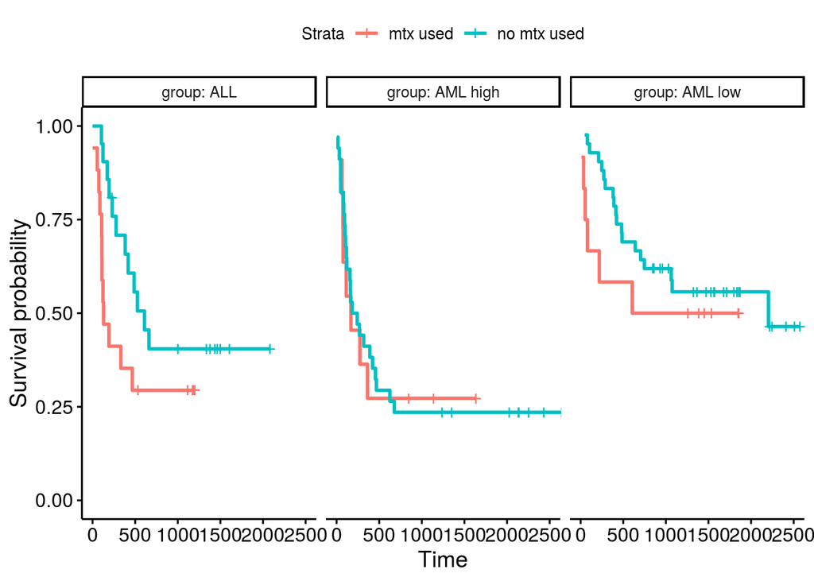

```r
#plot Kaplan-Meier disease-free survival curves for each of the 6 treatment/risk group category
bmtfit2<-survfit(Surv(t2,d3)~trt+group, data=bmt_dat)

ggsurvplot(bmtfit2, facet.by = "group", color = "trt")
```

```r
# Test whether the hazard rate between the MTX treatment groups differs when stratifying by the risk level
survdiff(Surv(t2,d3)~trt+strata(group), data=bmt_dat,rho=0)
```

```
## Call:
## survdiff(formula = Surv(t2, d3) ~ trt + strata(group), data = bmt_dat,
##     rho = 0)
##
##                  N Observed Expected (O-E)^2/E (O-E)^2/V
## trt=no mtx used 97       57     62.5     0.492      2.06
## trt=mtx used    40       26     20.5     1.504      2.06
##
##  Chisq= 2.1  on 1 degrees of freedom, p= 0.2
```

```r
survdiff(Surv(t2,d3)~trt+strata(group), data=bmt_dat,rho=1)
```

```
## Call:
## survdiff(formula = Surv(t2, d3) ~ trt + strata(group), data = bmt_dat,
##     rho = 1)
##
##                  N Observed Expected (O-E)^2/E (O-E)^2/V
## trt=no mtx used 97     37.3     43.3     0.822      4.51
## trt=mtx used    40     20.4     14.4     2.469      4.51
##
##  Chisq= 4.5  on 1 degrees of freedom, p= 0.03
```

```r
# What conclusion do you draw from this test?
```